# Reproducible Science with Rmarkdown

F. Rodriguez-Sanchez

Estacion Biologica de Donana (CSIC)  
@frod_san

Sevilla R  
25-11-2014

### Most science is not reproducible

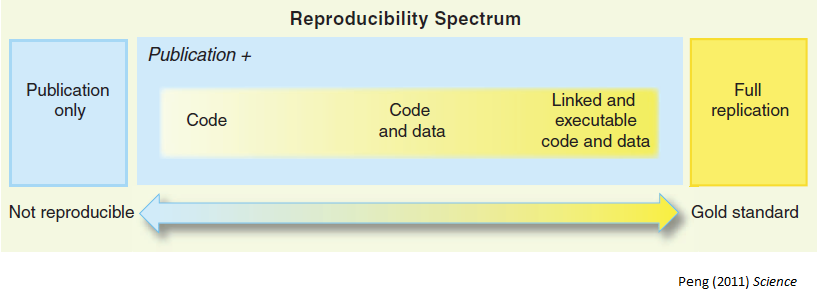

… even within the same lab group over time!

> Your closest collaborator is you 6 months ago, and you don't respond to emails.  
> P. Wilson

### Research workflow

1. Prepare data (**EXCEL**)

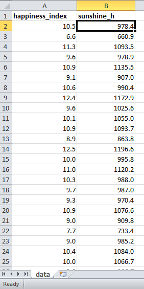

### Research workflow

1. Prepare data (**EXCEL**)
2. Analyse data (**R**)

[figure not shown]

### Research workflow

1. Prepare data (**EXCEL**)
2. Analyse data (**R**)
3. Write report/paper (**WORD**)

[figure not shown]

### This workflow is broken

[figure not shown]

### Problems of a broken workflow

- How did you do this? What analysis is behind this figure? Did you account for …?
- What dataset was used (e.g. final vs preliminary dataset)?
- Oops, there is an error in the data. Can you repeat the analysis? And update figures/tables in Word!

> A scientific article is advertising, not scholarship. The actual scholarship is the full software environment, code and data, that produced the result.  
> Claerbout & Karrenbach 1992

### Rmarkdown to the rescue!

[figure not shown]

knitr - pandoc - Rstudio

### Rmarkdown documents

- Fully reproducible (trace all results inc. tables and plots)
- Dynamic (regenerate with 1 click)
- Suitable for
  - documents (Word, PDF, etc)
  - presentations
  - books
  - websites
  - …

### Let's see it in action

In Rstudio, create new Rmarkdown document and click on `Knit HTML`.

Example project:

Does sunshine influence happiness?

See myproject.Rmd

[figure not shown]

### HTML output

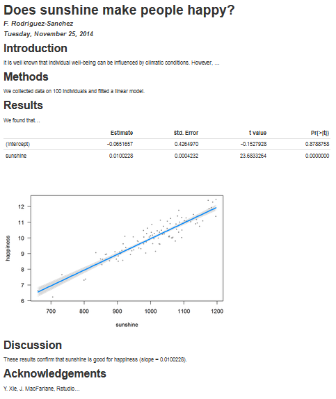

### Spotted error in the data? No problem!

Make changes in Rmarkdown document, click `knit` and report will update automatically!

### Other formats: PDF, Word

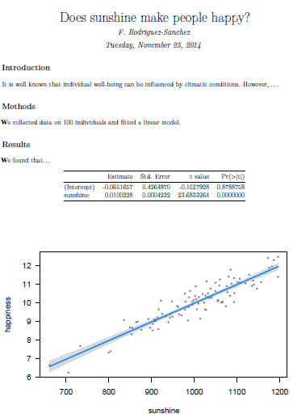

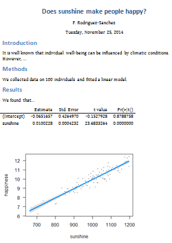

### Adding citations

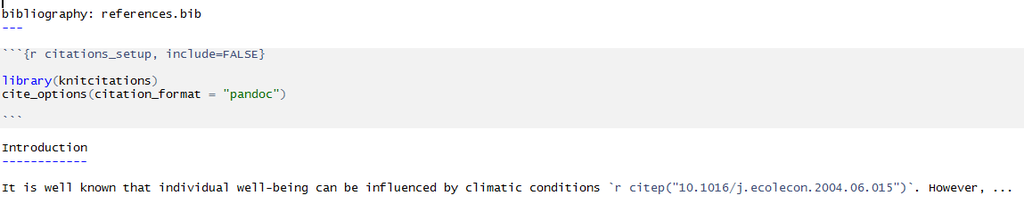

See output

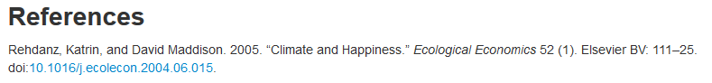

### Embedding data and Rmd source in HTML report

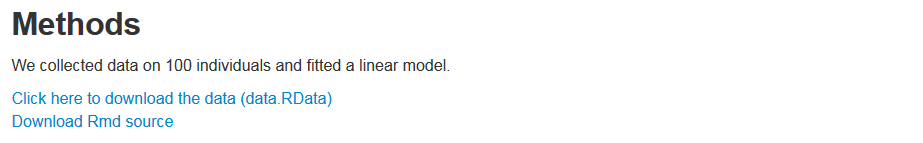

See myproject_embed.html

### Interactive documents: Rmarkdown + ggvis

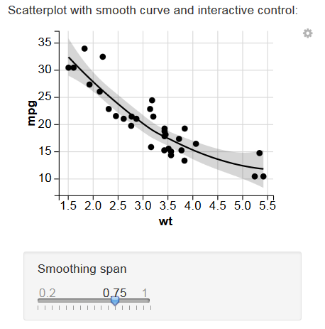

[See examples](http://127.0.0.1:4382/ggvis.Rmd)

## Give you and your collaborators a little treat

[figure not shown]

### Convert your old R scripts to Rmarkdown

- with [one click in RStudio](http://www.rstudio.com/ide/docs/authoring/markdown_notebooks)

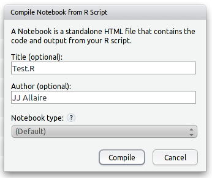

- using `knitr::spin`

### Leave behind your current workflow

[figure not shown]

### Combine Rmarkdown with version control (Git)

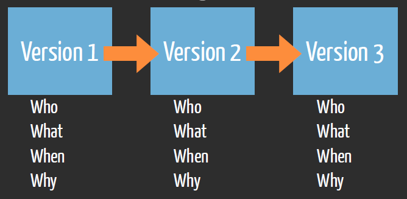

R. Fitzjohn (https://github.com/richfitz/reproducibility-2014)

### An efficient, fully reproducible workflow based on Rmarkdown and Git

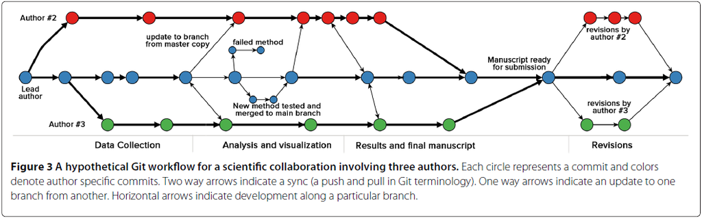

[K. Ram 2013](http://www.scfbm.org/content/8/1/7)

### Some useful links

- [Rmarkdown by RStudio](http://rmarkdown.rstudio.com/)
- [Course on Reproducible Research by K. Broman](http://kbroman.github.io/Tools4RR/)
- [Reproducible Research in Coursera](https://www.coursera.org/course/repdata)
- [Nice R code](http://nicercode.github.io/guides/reports/)
- [Reproducible Research with R and RStudio](http://christophergandrud.github.io/RepResR-RStudio/)
- [Ten simple rules for reproducible computational research](http://www.ploscompbiol.org/article/info%3Adoi%2F10.1371%2Fjournal.pcbi.1003285)

### More links (software/R packages)

- [CRAN Task View on Reproducible Research](http://cran.r-project.org/web/views/ReproducibleResearch.html)
- [knitr](http://yihui.name/knitr/)
- [pandoc](http://johnmacfarlane.net/pandoc/)
- [pander](http://rapporter.github.io/pander/)
- [rapport](http://rapport-package.info/)
- [reports](http://cran.r-project.org/web/packages/reports/index.html)
- [Rgitbook](http://jason.bryer.org/Rgitbook/)

### Find these slides at

- [GitHub](http://pakillo.github.io/Rmarkdown_talk_SevillaR_Nov2014)
- Figshare
- [Source code and materials](https://github.com/Pakillo/Rmarkdown_talk_SevillaR_Nov2014)